# Superstore dataset

Sargenti & Vallejo

2022-06-30

## 0.1 Objetivo

El presente documento tiene como objetivo el establecimiento de precios y cantidades para la maximización de los ingresos totales del SuperStore. Esto se podrá lograr a través del cumplimiento de los siguientes sub-objetivos:

1. Determinar si el segmento del cliente es independiente al tipo de producto.
2. Desarrollo de una metodologia del precio maximizador del ingreso total.
3. Metodología de promociones para la maximización del ingreso.

## 0.2 Desarrollo del Objetivo

Para el cumplimiento del objetivo propuesto se utilizará el algoritmo de regresión lineal. A partir del algoritmo de regresión, se obtendrán los coeficientes para la formación de la ecuación general de la demanda (Qd=B0 + B1*P), el porcentaje de variabilidad explicado por el modelo y el p-value. Este último validará el modelo una vez que sea menor a 0,05 con un nivel de confianza del 95%.

Ya validado el modelo, se obtiene la función de demanda, lo que permitirá calcular el ingreso total y así el precio maximizador del ingreso total. A su vez este procedimiento se realizará nuevamente, segmentando por categoría de producto, con el fin de evaluar diferencias entre los precios maximizadores.

A su vez se realiza un test de chi-cuadrado con el objetivo de evaluar si el segmento de clientes es o no independiente a la categoría del producto comprado.

Por último se utiliza nuevamente el algorítmo de regresión lineal para evaluar si los descuentos afectan al Ingreso Total. Esto se corroborará con el coeficiente de Pearson.

## 0.3 Descripción de las Variables a utilizar

La base SuperStore cuenta con 21 variables y 9994 registros.

```
##        Row ID      Order ID    Order Date     Ship Date     Ship Mode
##      "double"   "character"   "character"   "character"   "character"
##   Customer ID Customer Name       Segment       Country          City
##   "character"   "character"   "character"   "character"   "character"
##         State   Postal Code        Region    Product ID      Category
##   "character"      "double"   "character"   "character"   "character"
##  Sub-Category  Product Name         Sales      Quantity      Discount
##   "character"   "character"   "character"      "double"   "character"
##        Profit
##   "character"
```

Las variables que se utilizaron para hacer posible nuestro análisis relacionado al objetivo fueron:

1. “Segment”: Describe la categoría del cliente, la cuál puede variar entre Consumer, Corporate y Home Office. (Es de tipo Character)
2. “Category”: Describe la primera categoría por la cuál estan segmentados los productos. Entre ellas se encuentra Furniture, Technology y Office Supplies. (Es de tipo Character).
3. “Sales”:Describe el valor total de la compra realizada (Es de tipo Double).

4.”Quantity”:Describe la cantidad comprada del producto (Es de tipo Integer).

5. “Discount”: Describe el porcentaje de descuento aplicado a cada compra registrada.
6. “Product Name”: Hace referencia al nombre del producto comprado.

Ya que durante el análisis se precisa una variables que contenga el precio por unidad, para poder así determinar la demanda, se creó esta variable de tipo Double con el nombre de Price. Para esto, fue necesario hacer modificaciones en los tipo de dato de las variables Quatity y Sales. Para la unificación de los valores del data, se infirió sobre la variable Profit.

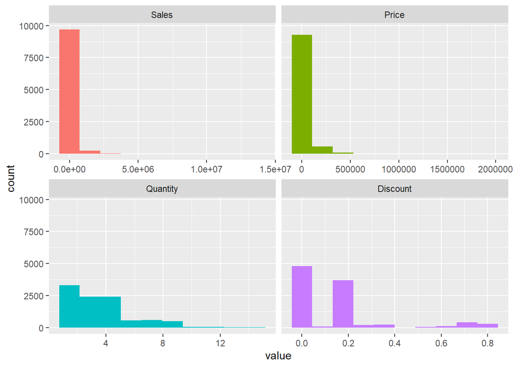

Las demas variables que no fueron nombradas, serán descartadas ya no que no fueron relevantes para el análisis del objetivo propuesto.

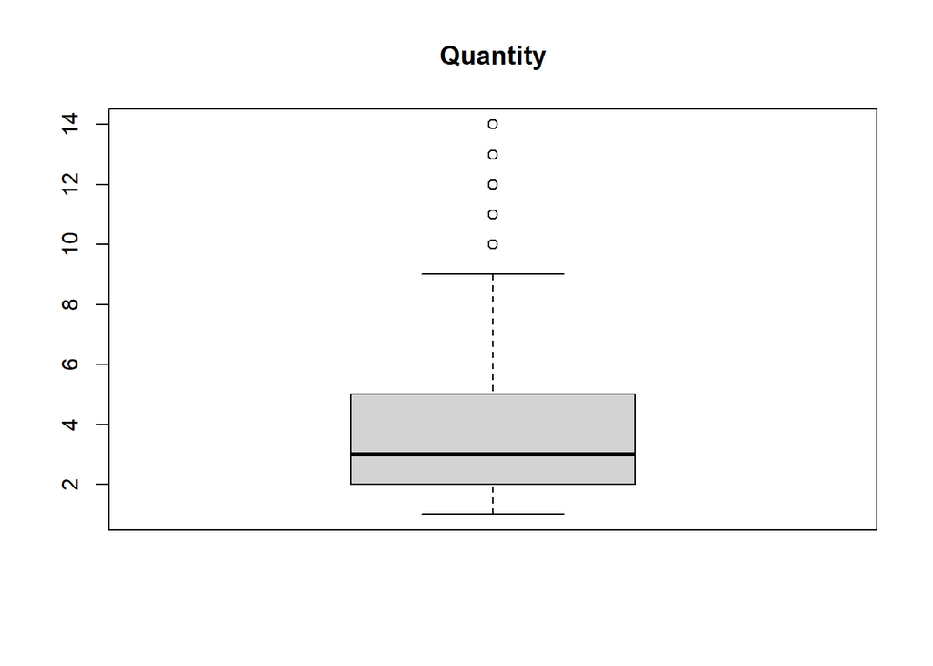

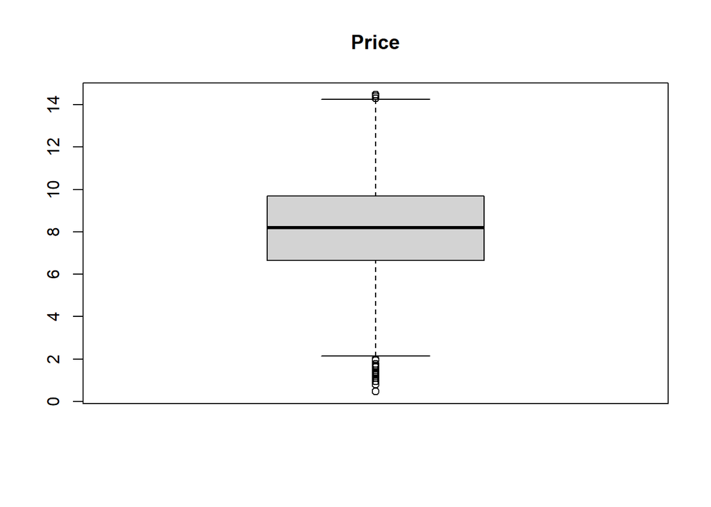

Si bien se encuentran outliers en las variables Sales y Price, estos no seran considerados como outliers, ya que la base presenta una división de productos con mucha variablidad entre sus precios. Es por eso que se decidió ver si en cada categoria de producto se encontraban outliers en estas variables.

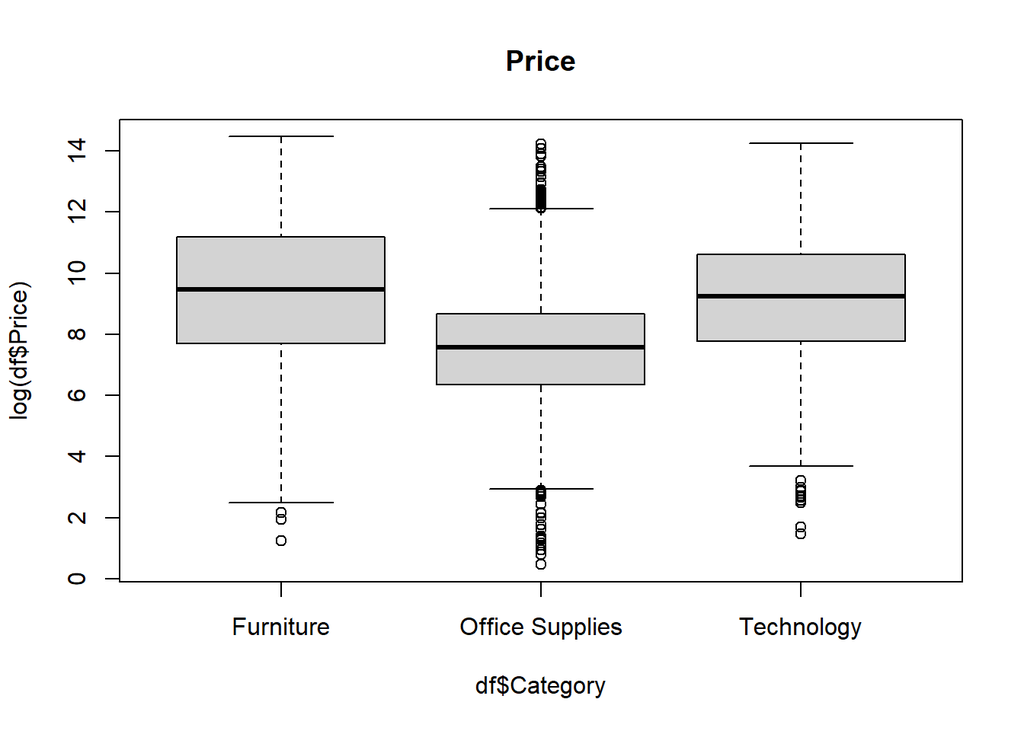

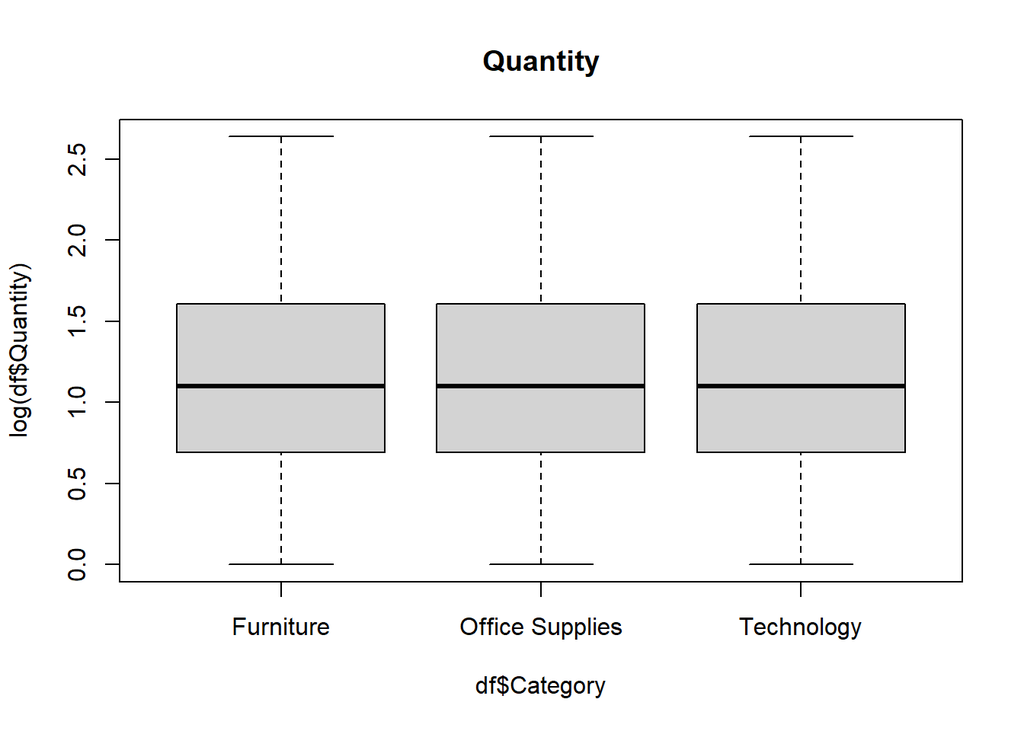

## 0.4 Lista de Variables

```
##      Sales             Quantity          Price             Category
##  Min.   :       3   Min.   : 1.000   Min.   :      1.6   Length:9994
##  1st Qu.:    2512   1st Qu.: 2.000   1st Qu.:    768.0   Class :character
##  Median :   11022   Median : 3.000   Median :   3621.8   Mode  :character
##  Mean   :  105972   Mean   : 3.789   Mean   :  29567.3
##  3rd Qu.:   53986   3rd Qu.: 5.000   3rd Qu.:  16112.2
##  Max.   :13523976   Max.   :14.000   Max.   :1915155.0
##  NA's   :6          NA's   :6        NA's   :6
##    Segment             Discount
##  Length:9994        Min.   :0.0000
##  Class :character   1st Qu.:0.0000
##  Mode  :character   Median :0.2000
##                     Mean   :0.1562
##                     3rd Qu.:0.2000
##                     Max.   :0.8000
##                     NA's   :6
```

A partir del resumen de cada variable, fue posible observar la gran magnitud entre los valores máximo y minímo de las variables númericas, en especial en Sales y Price. Esto es justificado debido a la gran variedad de productos, y en consecuencia a la difrencia entre las distintas sub categorías, y por lo tanto a la diferencia de precios entre sí.

## 0.5 Relación entre las Variables

Cantidad de compras por segmento por categoría

```
##        Segment Furniture Office Supplies Technology
## 1:    Consumer      4166           11758       3593
## 2:   Corporate      2495            7018       2088
## 3: Home Office      1367            4130       1226
```

```
## [1] "Office Supplies" "Office Supplies" "Office Supplies"
```

A partir de la tabla armada, es posible notar que en cada Segmento de clientes, el tipo de producto más consumido es del tipo Office Supplies. Esto podria deberse a que los productos que se encuentran dentro de esta categoría, son elementos de consumo diario y no requiere una mayor inversion su compra.

Continuado con el análisis, se quiere conocer si la categoría comprada es independiente al segmento de cliente. Por lo tanto, se construye el siguiente test de hipotesis: Test Chi-Square

H0: Las variables son independientes

H1: Las variables son dependientes

```
##
##  Pearson's Chi-squared test
##
## data:  independecia_variables
## X-squared = 1.4612, df = 4, p-value = 0.8335
```

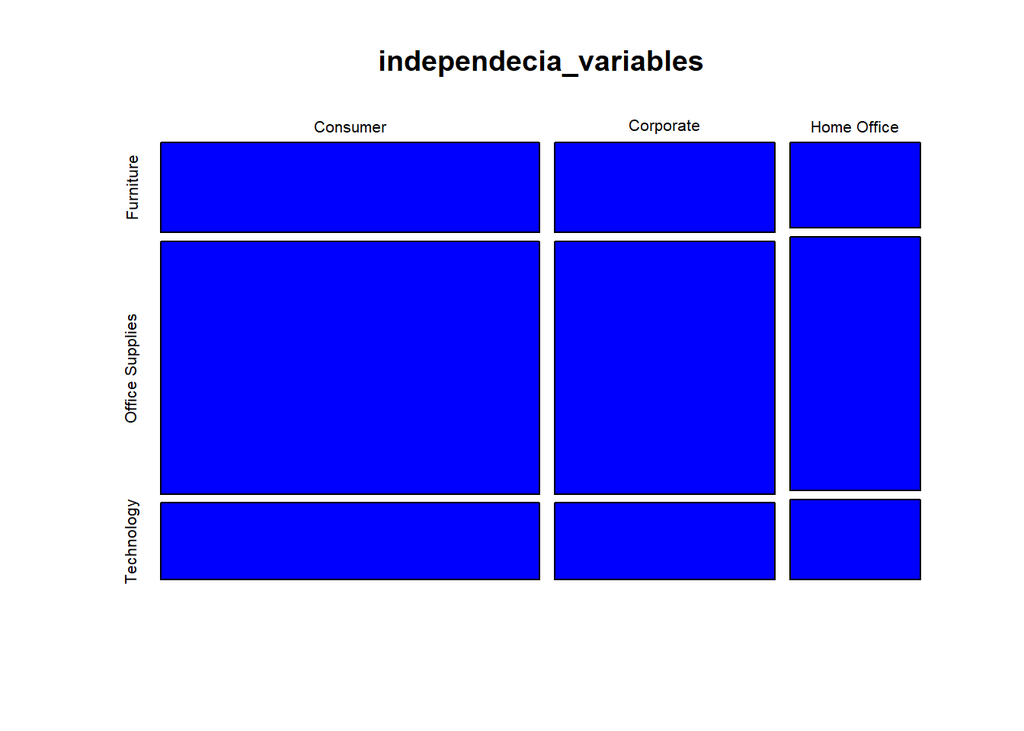

## 0.6 Técnicas de Análisis

Se quiere saber si existe algún tipo de relación entre la cantidad y el precio. Para ello, realizamos una regresión lineal de la demanda, al ser la regresión,la herramienta que nos permite encontrar una relación particular entre estas dos variables.

ECUACIÓN DE DEMANDA TOTAL

En primer lugar, se comienza con la validación del modelo. Esto permitirá saber si es posible continuar con el análisis o no. Para ello se formuló el siguiente test de hipotesis:

H0: El modelo no es válido

H1: El modelo si es válido

```
##
## Call:
## lm(formula = Quantity ~ Price, data = df)
##
## Residuals:
##    Min     1Q Median     3Q    Max
## -2.808 -1.801 -0.799  1.193 10.244
##
## Coefficients:
##               Estimate Std. Error t value Pr(>|t|)
## (Intercept)  3.808e+00  2.327e-02 163.626  < 2e-16 ***
## Price       -6.458e-07  2.300e-07  -2.808  0.00499 **
## ---
## Signif. codes:  0 '***' 0.001 '**' 0.01 '*' 0.05 '.' 0.1 ' ' 1
##
## Residual standard error: 2.224 on 9986 degrees of freedom
##   (6 observations deleted due to missingness)
## Multiple R-squared:  0.000789,   Adjusted R-squared:  0.000689
## F-statistic: 7.886 on 1 and 9986 DF,  p-value: 0.004993
```

```
##   (Intercept)         Price
##  3.807741e+00 -6.457898e-07
```

Se obtiene un p -value igual a 0.004993, el cual es menor a 0.05,por lo tanto se rechaza H0 y se concluye que el modelo es válido con un nivel de significación del 95%.

Posteriormente se analiza si la variable Price aporta de manera significativa o no al modelo.

H0: La variable Price no aporta al modelo propuesto

H1: La variable Price aporta al modelo propuesto

α = 0,05

CR: Pr(>|t|) < 0,05

Pr(>|t|) =0.00499

Teniendo en cuenta que el Pr(>|t|) =0.00499 , es posible rechazar H0 y por lo tanto concluir que el precio sí aporta al modelo.

A partir de esto se fórmula la ecuacion de demanda total:

Qd = 3.807741e+00 -6.457898e-07 * P

Luego se formula la ecuaciÓn de Ingreso total y el Ingreso Marginal:

IT = P*Q

IT = 3.807741e+00 P -6.457898e-07 * P**2

IMg = 3.807741e+00 -1.29158e-06 * P

El precio que maximiza el Ingreso Total es 2.9481263^{6}, mientras que la cantidad que maximiza es 2.

Por lo tanto el Ingreso total Maximizado es igual a 5.8962527^{6}

A continuacion se mostrara el grafico de la ecuacion de demanda general:

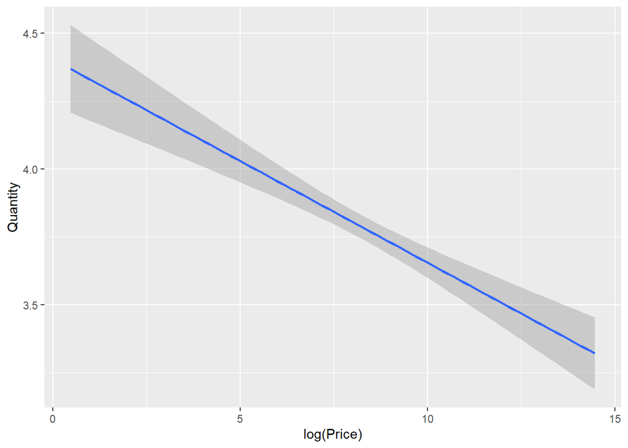

Debido a que los precios varian en relacion a cada categoría de producto, se consideró que es necesario evaluar la relación no solo entre cantidad y precio, sino también considerando la categoría del producto. Es por eso que se volvió a utilizar el algoritmo de regresión lineal, pero esta vez agregando la categoría del producto como una variable más en el análisis y el efecto fijo (0+).

DEMANDA POR CATEGORÍA DE PRODUCTO

Nuevamente se realiza el test de hipotésis para corroborar que el modelo sea válido.

H0: El modelo no es válido

H1: El modelo si es válido

```
##
## Call:
## lm(formula = Quantity ~ 0 + Category + Price, data = df)
##
## Residuals:
##     Min      1Q  Median      3Q     Max
## -2.8269 -1.7973 -0.7867  1.1911 10.2701
##
## Coefficients:
##                           Estimate Std. Error t value Pr(>|t|)
## CategoryFurniture        3.827e+00  5.064e-02  75.569  < 2e-16 ***
## CategoryOffice Supplies  3.809e+00  2.880e-02 132.268  < 2e-16 ***
## CategoryTechnology       3.782e+00  5.299e-02  71.375  < 2e-16 ***
## Price                   -6.509e-07  2.363e-07  -2.755  0.00589 **
## ---
## Signif. codes:  0 '***' 0.001 '**' 0.01 '*' 0.05 '.' 0.1 ' ' 1
##
## Residual standard error: 2.224 on 9984 degrees of freedom
##   (6 observations deleted due to missingness)
## Multiple R-squared:  0.7438, Adjusted R-squared:  0.7437
## F-statistic:  7246 on 4 and 9984 DF,  p-value: < 2.2e-16
```

Se obtiene un p -value < 2.2e-16, el cual es menor a 0.05, por lo tanto se rechaza H0 y se concluye que el modelo es válido con un nivel de significaciÓn del 95%.

Qué tanto explica el modelo?

Adjusted R-squared: 0.7437

A continuacion se realizará un analisis de la demanda por cada categoria de Producto:

CATEGORIA FURNITURE

H0: La variable Precio (Categoría Furniture) no aporta al modelo propuesto

H1: La variable Precio (Categoría Furniture) aporta al modelo propuesto

α = 0,05

CR: Pr(>|t|) < 0,05

A partir de esto se fórmula la ecuación de demanda de la categoría Furniture:

QdF = 3.827e+00 -6.509e-07 * P

Posteriormente se formula la ecuación de Ingreso total y el Ingreso Marginal para la categoría Furniture:

ITF = P*Q

ITF = 3.827e+00* P -6.509e-07 * P**2

A continuación se obtiene el precio y la cantidad que máximiza el Ingreso Total para la categoría Furniture.

El precio que maximiza el Ingreso Total para la categoría Furniture es 2.9630375^{6} y la cantidad es 2.

Por lo tanto el Ingreso total Maximizado para la categoría Furniture es 5.926075^{6}

CATEGORÍA OFFICE SUPPLIES

H0: La variable Precio (Categoría Office Supplies) no aporta al modelo propuesto

H1: La variable Precio (Categoría Office Supplies) aporta al modelo propuesto

α = 0,05

CR: Pr(>|t|) < 0,05

A partir de esto se formula la ecuación de demanda de la categoría Office Supplies:

QdS = 3.809e+00 -6.509e-07 * P

Posteriormente se formula la ecuación de Ingreso total y el Ingreso Marginal para la categoría Office Supplies:

ITS = P*Q

ITS = 3.809e+00* P - 6.509e-07 * P**2

A continuación se obtiene el precio y la cantidad que maximiza el Ingreso Total para la categoría Office Supplies.

El precio que maximiza el Ingreso Total para la categoría Office Supplies es 2.9491011^{6} y la cantidad es 2.

Por lo tanto el Ingreso total Maximizado para la categoría Office Supplies es 5.8982022^{6}

CATEGORÍA TECHNOLOGY

H0: La variable Precio (Categoría Technology) no aporta al modelo propuesto

H1: La variable Precio (Categoría Technology) aporta al modelo propuesto

α = 0,05

CR: Pr(>|t|) < 0,05

A partir de esto se formula la ecuación de demanda de la categoria Technology:

QdT = 3.782e+00 - 6.509e-07 * P

Posteriormente se formula la ecuación de Ingreso total y el Ingreso Marginal para la categoría Technology:

ITT = P*Q

ITT = 3.782e+00* P - 6.509e-07 * P**2

A continuación se obtiene el precio y la cantidad que maximiza el Ingreso Total para la categoría Technology

```
## [1] 2948126
```

```
## [1] 2963038
```

```
## [1] 2949101
```

```
## [1] 2928196
```

Se indentifica cuales son los productos por categoría que se acercan al precio maximizador. CATEGORÍA OFFICE SUPPLIES

```r
df%>% filter(Category=="Office Supplies", Price>=1500000) %>% group_by(`Product Name`)
```

```
## # A tibble: 1 x 22
## # Groups:   Product Name [1]
##   `Row ID` `Order ID`     `Order Date` `Ship Date` `Ship Mode`  `Customer ID`
##      <dbl> <chr>          <chr>        <chr>       <chr>        <chr>
## 1     7819 CA-2016-138478 10/21/2016   10/26/2016  Second Class DP-13390
## # ... with 16 more variables: `Customer Name` <chr>, Segment <chr>,
## #   Country <chr>, City <chr>, State <chr>, `Postal Code` <dbl>, Region <chr>,
## #   `Product ID` <chr>, Category <chr>, `Sub-Category` <chr>,
## #   `Product Name` <chr>, Sales <dbl>, Quantity <dbl>, Discount <dbl>,
## #   Profit <dbl>, Price <dbl>
```

CATEGORÍA FURNITURE

```r
df%>% filter(Category=="Furniture", Price>=1900000) %>% group_by(`Product Name`)
```

```
## # A tibble: 2 x 22
## # Groups:   Product Name [1]
##   `Row ID` `Order ID`     `Order Date` `Ship Date` `Ship Mode`    `Customer ID`
##      <dbl> <chr>          <chr>        <chr>       <chr>          <chr>
## 1        4 US-2015-108966 42318        10/18/2015  Standard Class SO-20335
## 2     8207 CA-2015-122266 4/26/2015    4/30/2015   Standard Class SA-20830
## # ... with 16 more variables: `Customer Name` <chr>, Segment <chr>,
## #   Country <chr>, City <chr>, State <chr>, `Postal Code` <dbl>, Region <chr>,
## #   `Product ID` <chr>, Category <chr>, `Sub-Category` <chr>,
## #   `Product Name` <chr>, Sales <dbl>, Quantity <dbl>, Discount <dbl>,
## #   Profit <dbl>, Price <dbl>
```

CATEGORIA TECHNOLOGY

```r
df%>% filter(Category=="Technology", Price>=1500000) %>% group_by(`Product Name`)
```

```
## # A tibble: 1 x 22
## # Groups:   Product Name [1]
##   `Row ID` `Order ID`     `Order Date` `Ship Date` `Ship Mode` `Customer ID`
##      <dbl> <chr>          <chr>        <chr>       <chr>       <chr>
## 1      978 CA-2017-159366 42917        43009       First Class BW-11110
## # ... with 16 more variables: `Customer Name` <chr>, Segment <chr>,
## #   Country <chr>, City <chr>, State <chr>, `Postal Code` <dbl>, Region <chr>,
## #   `Product ID` <chr>, Category <chr>, `Sub-Category` <chr>,
## #   `Product Name` <chr>, Sales <dbl>, Quantity <dbl>, Discount <dbl>,
## #   Profit <dbl>, Price <dbl>
```

A continuación se mostrará el gráfico de demanda por cada categoría:

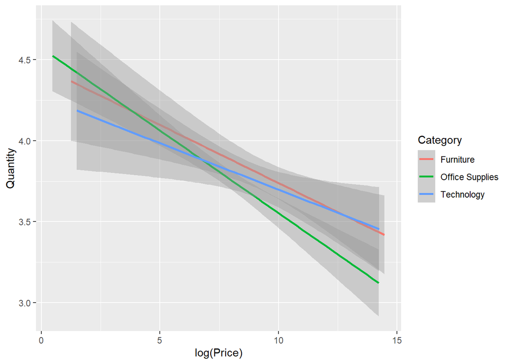

Con el objetivo de de hallar cuál de las tres categorías presentar una mayor variación en la cantidad demandada ante una varición en el preciO, se analiza la elaticidad de la demanda por categoría.

ELASTICIDAD

```
##
## Call:
## lm(formula = log(Quantity) ~ log(Price), data = df)
##
## Residuals:
##      Min       1Q   Median       3Q      Max
## -1.34117 -0.44818 -0.03665  0.40060  1.54747
##
## Coefficients:
##             Estimate Std. Error t value Pr(>|t|)
## (Intercept)  1.36807    0.02295  59.608   <2e-16 ***
## log(Price)  -0.02449    0.00270  -9.069   <2e-16 ***
## ---
## Signif. codes:  0 '***' 0.001 '**' 0.01 '*' 0.05 '.' 0.1 ' ' 1
##
## Residual standard error: 0.5837 on 9986 degrees of freedom
##   (6 observations deleted due to missingness)
## Multiple R-squared:  0.008169,   Adjusted R-squared:  0.00807
## F-statistic: 82.25 on 1 and 9986 DF,  p-value: < 2.2e-16
```

```
## (Intercept)  log(Price)
##  1.36807417 -0.02449035
```

GRÁFICO ELASTICIDAD

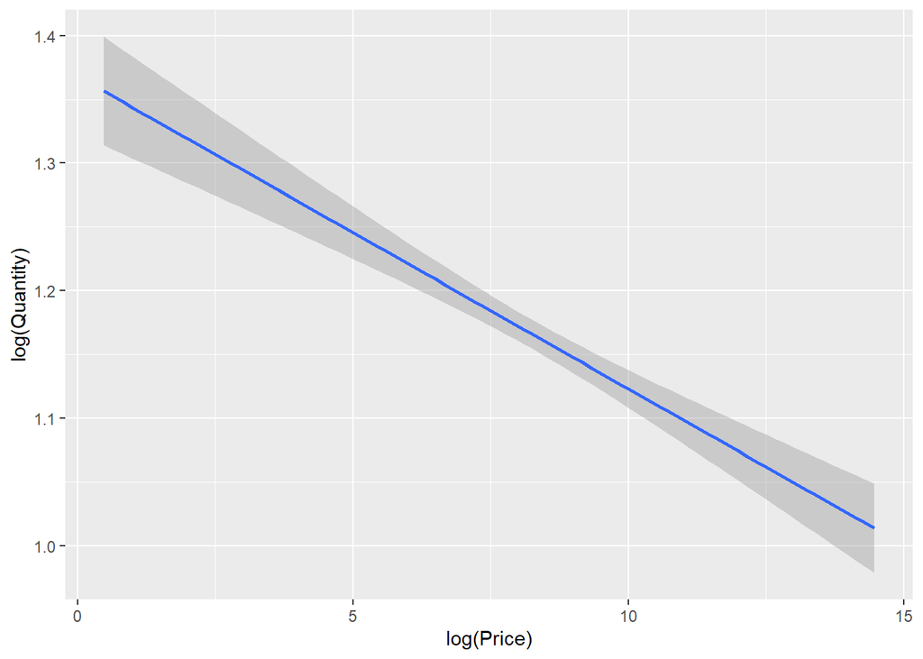

ELASTICIDAD POR CATEGORÍA

FURNITURE

```
##
## Call:
## lm(formula = log(df_furniture$Quantity) ~ log(df_furniture$Price))
##
## Residuals:
##      Min       1Q   Median       3Q      Max
## -1.28078 -0.43072 -0.02374  0.40818  1.51563
##
## Coefficients:
##                          Estimate Std. Error t value Pr(>|t|)
## (Intercept)              1.408930   0.055758  25.269  < 2e-16 ***
## log(df_furniture$Price) -0.026165   0.005804  -4.508  6.9e-06 ***
## ---
## Signif. codes:  0 '***' 0.001 '**' 0.01 '*' 0.05 '.' 0.1 ' ' 1
##
## Residual standard error: 0.5848 on 2119 degrees of freedom
## Multiple R-squared:  0.0095, Adjusted R-squared:  0.009033
## F-statistic: 20.32 on 1 and 2119 DF,  p-value: 6.896e-06
```

```
##             (Intercept) log(df_furniture$Price)
##              1.40893041             -0.02616544
```

Una disminución a la baja en el precio de furniture NO genera un impacto en la cantidad demandada al tener una elasticidad baja

OFFICE SUPPLIES

```
##
## Call:
## lm(formula = log(df_Office$Quantity) ~ log(df_Office$Price))
##
## Residuals:
##      Min       1Q   Median       3Q      Max
## -1.38513 -0.44683 -0.03497  0.38624  1.56120
##
## Coefficients:
##                       Estimate Std. Error t value Pr(>|t|)
## (Intercept)           1.421625   0.031275  45.456   <2e-16 ***
## log(df_Office$Price) -0.033216   0.004014  -8.275   <2e-16 ***
## ---
## Signif. codes:  0 '***' 0.001 '**' 0.01 '*' 0.05 '.' 0.1 ' ' 1
##
## Residual standard error: 0.5832 on 6024 degrees of freedom
## Multiple R-squared:  0.01124,    Adjusted R-squared:  0.01108
## F-statistic: 68.48 on 1 and 6024 DF,  p-value: < 2.2e-16
```

```
##          (Intercept) log(df_Office$Price)
##           1.42162485          -0.03321554
```

Una disminución a la baja en el precio de office supplies genera un impacto en la cantidad demandada al tener la mayor elasticidad

TECHNOLOGY

```
##
## Call:
## lm(formula = log(df_Technology$Quantity) ~ log(df_Technology$Price))
##
## Residuals:
##     Min      1Q  Median      3Q     Max
## -1.2578 -0.4454 -0.0393  0.4334  1.5172
##
## Coefficients:
##                           Estimate Std. Error t value Pr(>|t|)
## (Intercept)               1.304556   0.057746  22.591  < 2e-16 ***
## log(df_Technology$Price) -0.016187   0.006196  -2.612  0.00906 **
## ---
## Signif. codes:  0 '***' 0.001 '**' 0.01 '*' 0.05 '.' 0.1 ' ' 1
##
## Residual standard error: 0.5822 on 1839 degrees of freedom
##   (6 observations deleted due to missingness)
## Multiple R-squared:  0.003698,   Adjusted R-squared:  0.003156
## F-statistic: 6.825 on 1 and 1839 DF,  p-value: 0.009062
```

```
##              (Intercept) log(df_Technology$Price)
##               1.30455623              -0.01618662
```

Una disminución a la baja en el precio de technology NO genera un impacto en la cantidad demandada al tener la menor elasticidad. Menos elástica.

GRÁFICO ELASTICIDAD por categoría

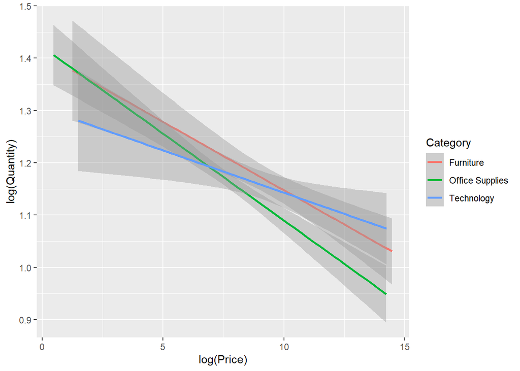

METODOLOGíA DE PROMOCIONES

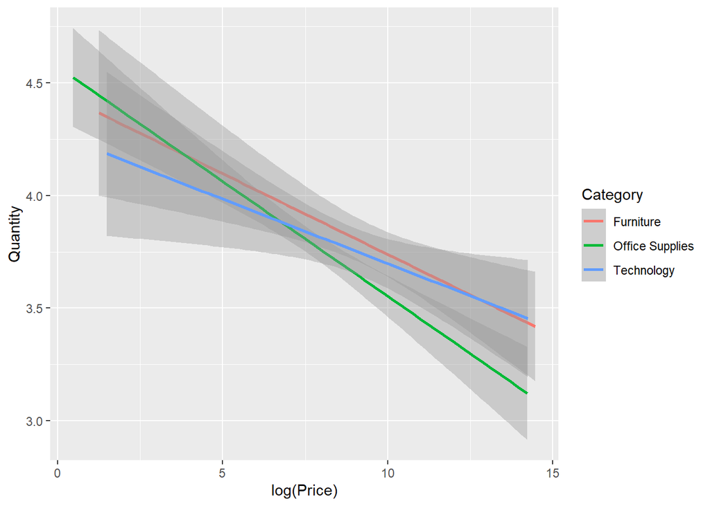

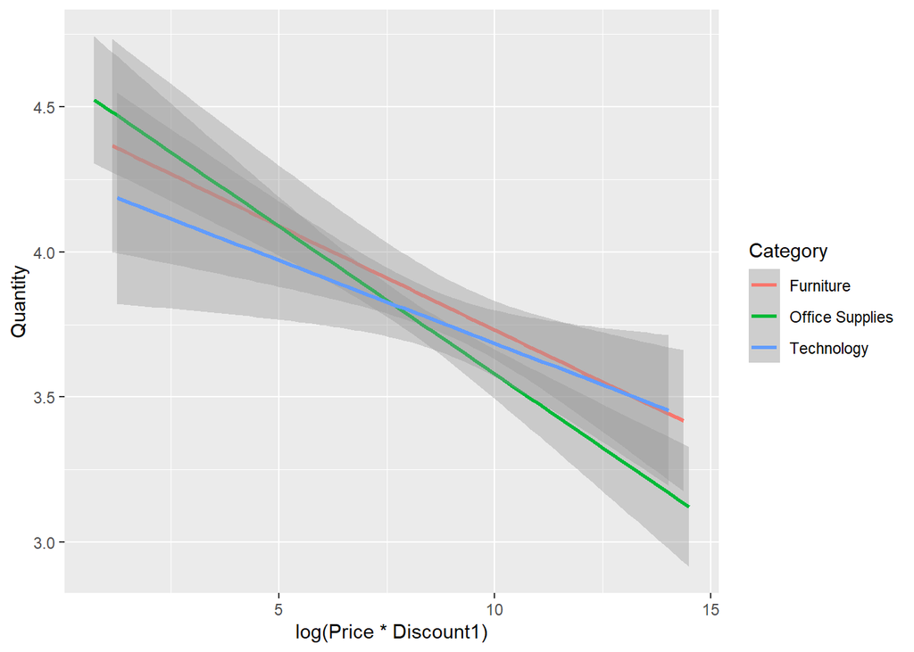

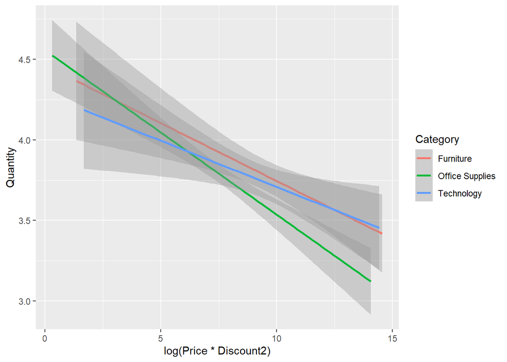

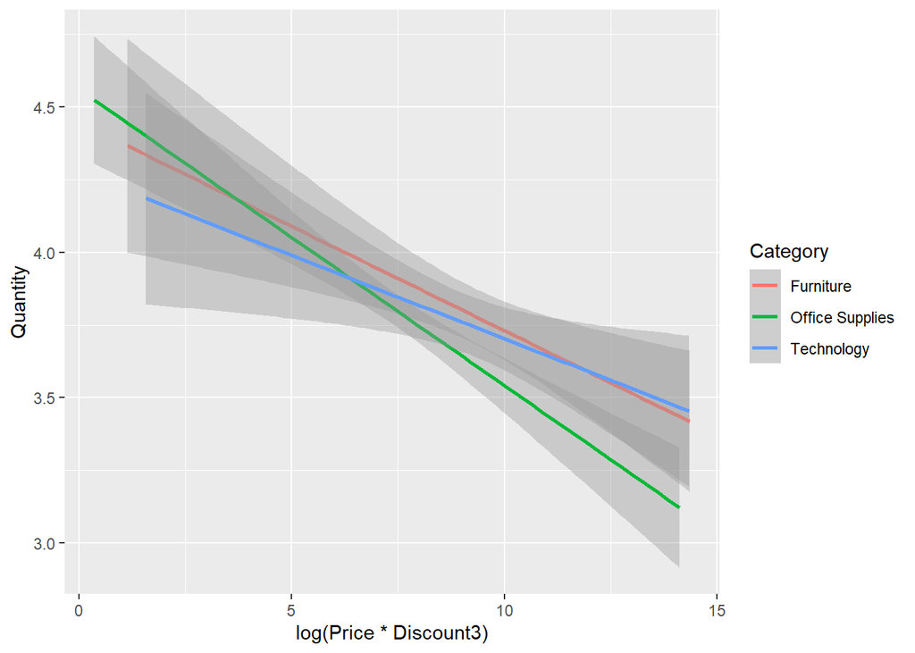

```
## [1] "Precio sin descuento"
```

```
## [1] 1e+05
```

```
## [1] "Ingreso sin descuento "
```

```
## [1] 410000
```

```
## [1] "Precio con descuento 1"
```

```
## [1] 90000
```

```
## [1] "Ingreso con descuento 1"
```

```
## [1] 369000
```

```
## [1] "Precio con descuento 2"
```

```
## [1] 110000
```

```
## [1] "Ingreso con descuento 2"
```

```
## [1] 451000
```

```
## [1] "Precio con descuento 3"
```

```
## [1] 90000
```

```
## [1] "Ingreso con descuento 3"
```

```
## [1] 369000
```

```
## [1] "Precio sin descuento"
```

```
## [1] 1e+05
```

```
## [1] "Ingreso sin descuento"
```

```
## [1] 4e+05
```

```
## [1] "Precio con descuento 1"
```

```
## [1] 80000
```

```
## [1] "Ingreso con descuento 1"
```

```
## [1] 320000
```

```
## [1] "Precio con descuento 2"
```

```
## [1] 120000
```

```
## [1] "Ingreso con descuento 2"
```

```
## [1] 480000
```

```
## [1] "Precio con descuento 3"
```

```
## [1] 110000
```

```
## [1] "Ingreso con descuento 3"
```

```
## [1] 440000
```

```
## [1] "Precio sin descuento"
```

```
## [1] 1e+05
```

```
## [1] "Ingreso sin descuento"
```

```
## [1] 410000
```

```
## [1] "Precio con descuento 1"
```

```
## [1] 130000
```

```
## [1] "Ingreso con descuento 1"
```

```
## [1] 520000
```

```
## [1] "Precio con descuento 2"
```

```
## [1] 85000
```

```
## [1] "Ingreso con descuento 2"
```

```
## [1] 348500
```

```
## [1] "Precio con descuento 3"
```

```
## [1] 90000
```

```
## [1] "Ingreso con descuento 3"
```

```
## [1] 369000
```

```
## [1] "Ingreso tot SIN promo"
```

```
## [1] 1220000
```

```
## [1] "Ingreso tot SIN promo 1"
```

```
## [1] 1209000
```

```
## [1] "Ingreso tot SIN promo 2"
```

```
## [1] 1279500
```

```
## [1] "Ingreso tot promo 3"
```

```
## [1] 1178000
```

```
## [1] "Diferencia promo 2 y 1"
```

```
## [1] 70500
```

```
## [1] "Diferencia promo 2 y 3"
```

```
## [1] 101500
```

```
## [1] "Diferencia promo 2 y sin promo "
```

```
## [1] 59500
```

## 0.7 Conclusión

Se concluye que existe una correlación entre precio de producto y cantidad comprada lo cuál fue posible establecer mediante regresión, permitiendo la maximización del ingreso total mediante el precio y cantidad maximizadores. A su vez también es posible afirmar que el precio maximizador puede variar por categoría de producto.

Por último, se buscó determinar de 3 promociones cuál es aquella que maximiza el ingreso total. La óptima fue la promoción 2, donde se incrementan los precios de Furniture y Technology mientras que se disminue el precio para Office Supplies.